# Assignment_3

Shritej Chavan (BE14B004)

September 26, 2018

### Q.1 ARIMA process

1. Parametrization of h[.]
2. AR(2) model :
   $$H_1(q^{-1}) = \frac{1}{1 - 0.8q^{-1} + 0.12q^{-2}}$$

Factorizing the denominator , we get

$$H_1(q^{-1}) = \frac{1}{(1 - 0.6q^{-1})(1 - 0.2q^{-1})}$$
Therefore

$$H_1 (q^{-1}) = \frac{1}{2}\left( \frac{3}{1-(0.6)q^{-1}} - \frac{1}{1-0.2q^{-1}} \right)$$

From binomial expansion, we get

$$H_1 (q^{-1}) = \frac{1}{2}\left( 3\sum_{n=0}^{\infty} 0.6^n q^{-n} - \sum_{n=0}^{\infty} 0.2^nq^{-n}\right)$$
Therefore,

$$h[n] = \frac{1}{2}\left( 3*0.6^n - 0.2^n\right) ......\forall n \geq 0$$

2. ARMA(1,1) process
   $$H_2(q^{-1}) = \frac{1 + 0.3q^{-1}}{1 - 0.6q^{-1}}$$
   After binomial expansion of the given transfer function operator, we get

$$H(q^{-1}) = (1+0.3q^{-1})(\sum_{n = 0}^\infty 0.6^n q^{-n})$$

Therfore

$$h[n] = 0.6^n + 0.3(0.6^n).....\forall n > 0$$

2. ARIMA

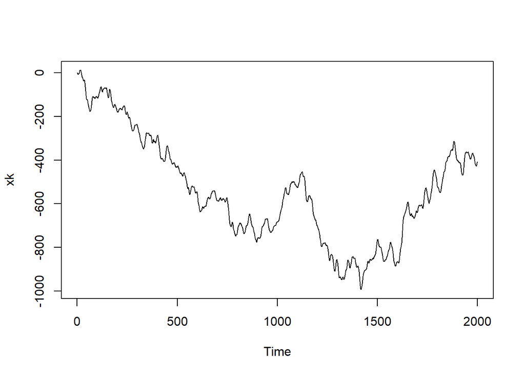

```r
#Loading the given time series
load("a3_q1.Rdata")
#Plotting the time series
plot(xk)
```

In the above plot of the given series we can clearly see that the series is not stationary

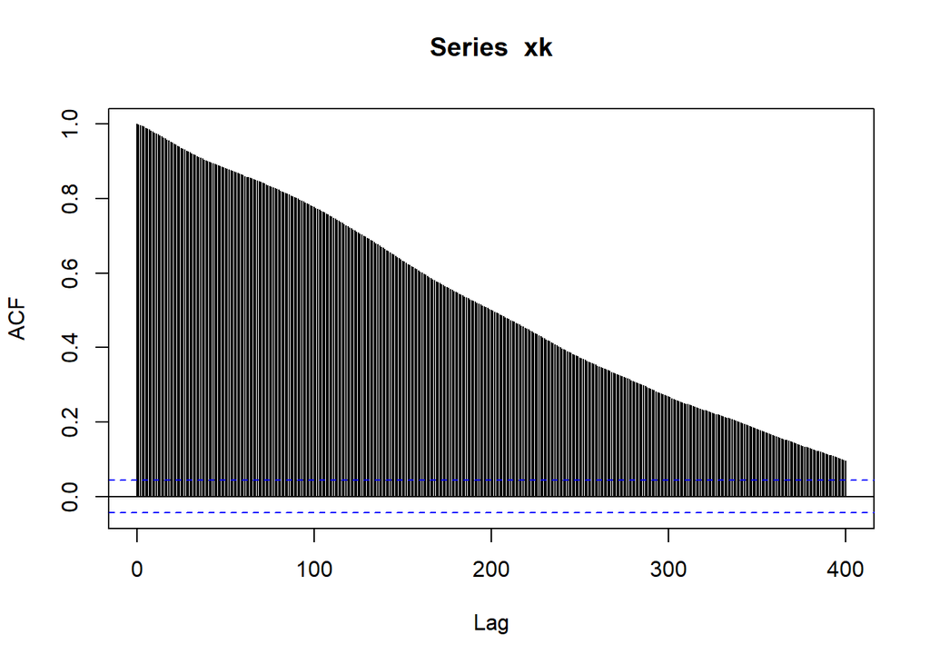

```r
#Plotting the ACF and PACF of the given time series

acf(xk, lag.max = 400)
```

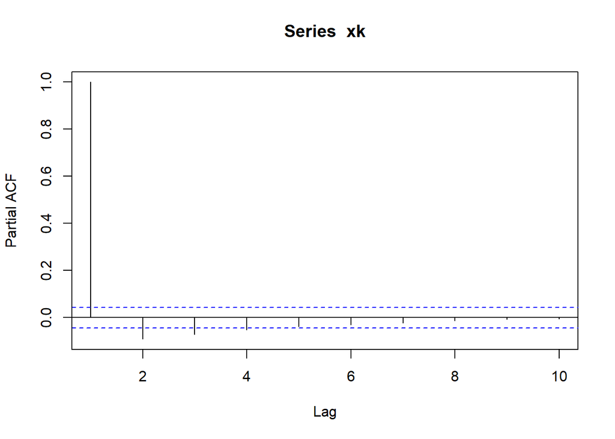

```r
pacf(xk,lag.max = 10)
```

Now, observing the ACF and PACF of the given series and ASSUMING it to be STATIONARY, we will fit an AR(4) model given the abrupt change in the PACF after lag - 4.

```r
arPmod <- arima(xk,order=c(4,0,0), include.mean = FALSE)
print(arPmod)
```

```
##
## Call:
## arima(x = xk, order = c(4, 0, 0), include.mean = FALSE)
##
## Coefficients:
##          ar1      ar2     ar3      ar4
##       2.6742  -2.5958  1.0960  -0.1743
## s.e.  0.0220   0.0588  0.0588   0.0220
##
## sigma^2 estimated as 1.007:  log likelihood = -2847.35,  aic = 5704.7
```

Now checking the coefficients of the above AR(4) model and it’s S.E we can clearly see that [ar_i - 3(se_i), ar_i + 3(se_i)] does not include zero. Test for Overfitting passed.

Checking for underfitting, we plot the residuals

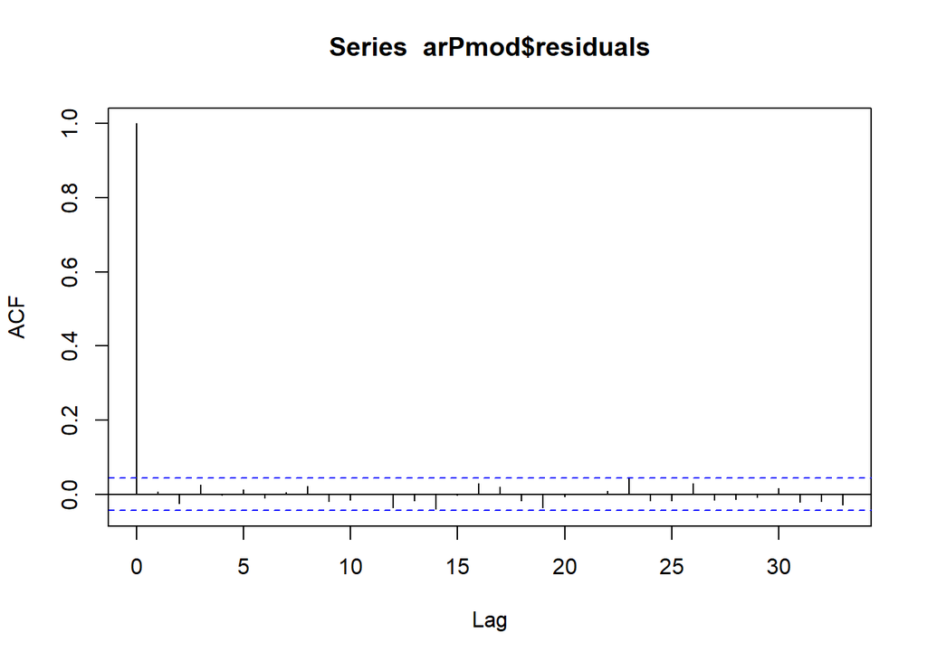

```r
acf(arPmod$residuals)
```

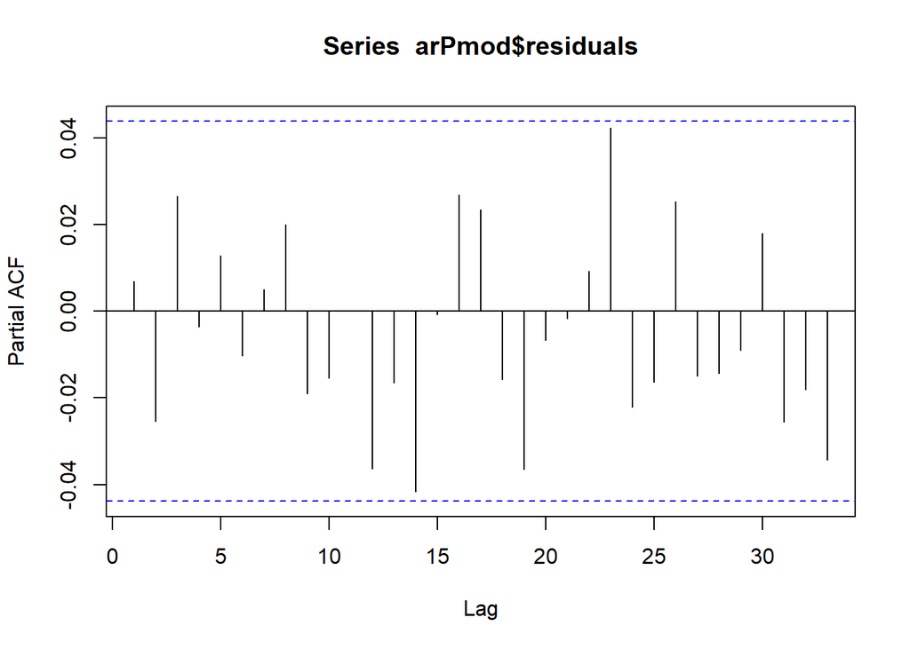

```r
pacf(arPmod$residuals)
```

Since the residuals clearly shows the white-noise characteristics we can say the model has passed the underfitting test

Now since we assumed the above series which clearly non - stationary (by observation) as a stationary process we will filter out non-stationarity by differencing

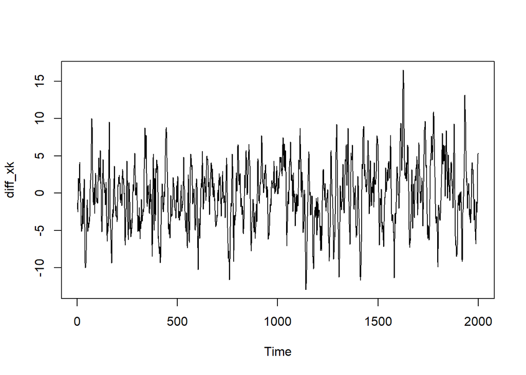

```r
diff_xk <- diff(xk)
plot(diff_xk)
```

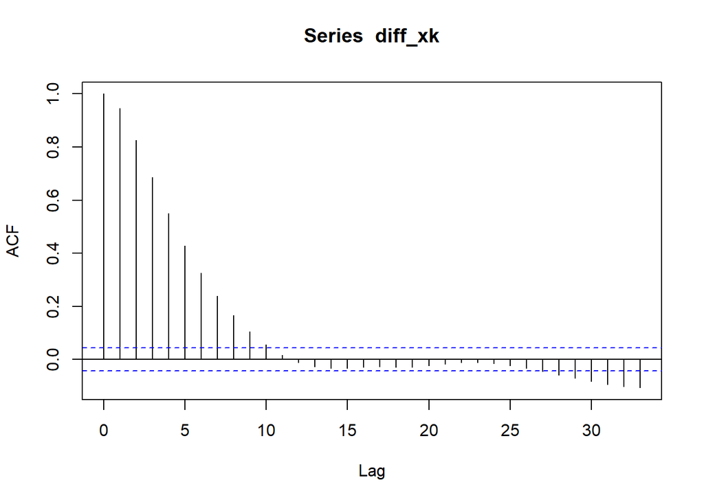

```r
acf(diff_xk)
```

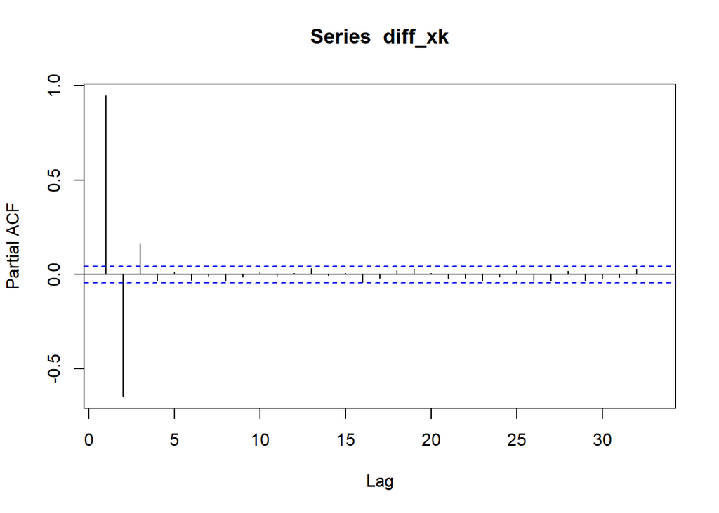

```r
pacf(diff_xk)
```

Observing the ACF and PACF of the differenced series we can either assume MA(10) or AR(3) process for the differenced series

```r
ma10mod <- arima(diff_xk,c(0,0,10))
print(ma10mod)
```

```
##
## Call:
## arima(x = diff_xk, order = c(0, 0, 10))
##
## Coefficients:
##          ma1     ma2     ma3     ma4     ma5     ma6     ma7     ma8
##       1.6839  1.8658  1.7602  1.4967  1.1871  0.8722  0.5992  0.3912
## s.e.  0.0224  0.0438  0.0598  0.0685  0.0694  0.0657  0.0621  0.0574
##          ma9    ma10  intercept
##       0.2039  0.0555    -0.1952
## s.e.  0.0444  0.0234     0.2498
##
## sigma^2 estimated as 1.013:  log likelihood = -2850.68,  aic = 5725.37
```

Looking at the coefficients we can clearly see that the MA(10) model has overfitted the parameters, Therefore MA(10) model is rejected

Therefore moving on to AR(3) process

```r
ar3mod <- arima(diff_xk,c(3,0,0))
print(ar3mod)
```

```
##
## Call:
## arima(x = diff_xk, order = c(3, 0, 0))
##
## Coefficients:
##         ar1      ar2    ar3  intercept
##       1.674  -0.9213  0.174    -0.1897
## s.e.  0.022   0.0382  0.022     0.3053
##
## sigma^2 estimated as 1.008:  log likelihood = -2845.78,  aic = 5701.57
```

Since the coefficients passes the overfitting test we can now check the residuals

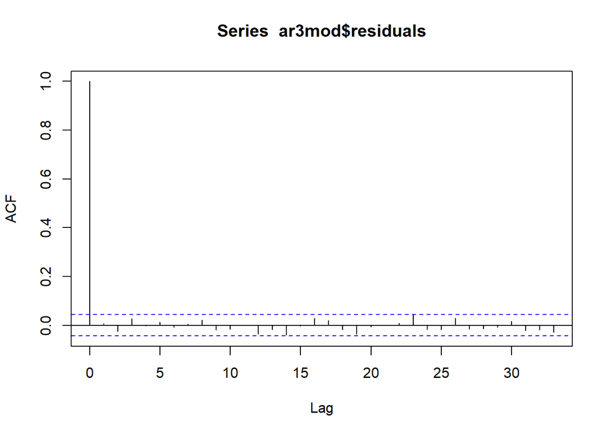

```r
acf(ar3mod$residuals)
```

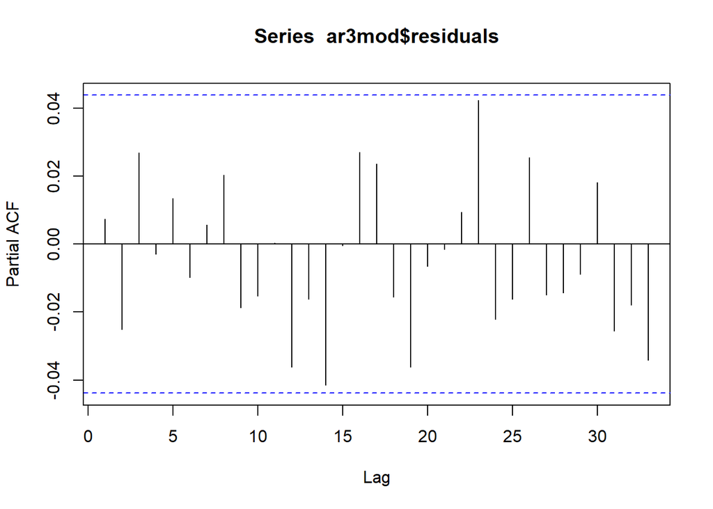

```r
pacf(ar3mod$residuals)
```

Since the residuals clearly shows the white-noise characteristics we can say the model has passed the underfitting test

Now comparing the sigma of the residuals and the aic of the process

$\sigma_{d3} > \sigma_4$ (slightly) and $AIC_{d3} < AIC_4$

Now the test of parsimony comes to the rescue, showing that the AR(3) model on the differenced series is the appropriate fit with coefficients shown by the $ar3mod$ var above.

Therefore, to conclude the given series can be fitted by ARIMA(3,1,0) model with coefficients same as $ar3mod$ where 1 stands for ARMA(3,0) model on the series that is differenced 1 time.

3. The given process

$$v[k] = -d_1v[k-1] + e[k]$$
In the above equation substituting the value of $v[k-1]$ and $v[k-2]$ subsequently, we get

$$v[k] = -d_1^3v[k-3] + e[k] -d_1e[k-1] + d_1^2e[k-2]$$

Therefore

$$\hat{v}[k|k-3] = -d_1^3v[k-3]$$
Therefore

$$error = v[k] - \hat{v}[k|k-3]$$

$$error = e[k] -d_1e[k-1] + d_1^2e[k-2]$$

$$\sigma_{error} = (1 + d_1^2 + d_1^4)\sigma_e^2$$
###Q.2 Computing correlations

The given process is

$$y[k] = \frac{b_2^0q^{-2}}{1+f_1^0q^{-1}}u[k] + e[k]$$
where, u[k] and e[k] both are Gaussian WN processes with zero mean.

Therefore, $E(y[k]) = 0 $

$$\sigma_{yy}[l] = E(y[k]y[[k-l]) = -f_1^0\sigma_{yy}[l-1] + b_2^0\sigma_{uy}[l-2] + \sigma_{ey}[l] + f_1^0\sigma_{ey}[l-1]$$
Substituting the values for lag = 0 and 1, we get

$$\sigma_{yy}[0] = -f_1^0\sigma_{yy}[1] + b_2^0\sigma_{uy}[2] + \sigma_e^2 .....(1)$$

$$\sigma_{yy}[1] = -f_1^0\sigma_{yy}[0] + b_2^0\sigma_{uy}[1] + f_1^0\sigma_e^2 . . . . .(2)$$
$$\sigma_{yu}[l] = E(y[k]u[k-l]) = -f_1^0\sigma_{yu}[l-1] + b_2^0\sigma_{uu}[l-2] .......(3)$$

$$\sigma_{yu}[1] = -f_1^0\sigma_{yu}[0].....(4)$$
$$\sigma_{yu}[0] = -f_1^0\sigma_{yu}[1] . . ....(5)$$
$$\sigma_{yu}[2] = -f_1^0\sigma_{yu}[1] + b_2^0\sigma_{uu}[0].....(6)$$
From equation (4) & (5), we get

$$\sigma_{yu}[0] = \sigma_{yu}[1] = 0$$
From equation (6), we get

$$\sigma_{yu}[2] = b_2^0\sigma_u^2$$
Solving for (1) and (2) we get

$$\sigma_{y}^2 = \frac{(b_2^0)^2}{1-(f_1^0)^2}\sigma_u^2 +\sigma_e^2$$

Also,

$$\sigma_{yy}[1] = (b_2^0)^2 \frac{-f_1^0}{1-(f_1^0)^2}\sigma^2_u$$

From equation (3), substituting the value of lag = 3, we get

$$\sigma_{yu}[3] = -f_1^0\sigma_{yu}[2] = - b_2^0f_1^0\sigma_u^2$$
Similarly for lag = 4, we get

$$\sigma_{yu}[3] = -f_1^0\sigma_{yu}[3] = b_2^0(f_1^0)^2\sigma_u^2$$
Therefore we can see that,

$$\frac{\sigma_{yu}[l]}{\sigma_{yu}[2]} = (-f_1^0)^{l-2} .....\forall l\geq2$$

Since, $|f_0^1| < 1$ therefore above correlation we keep decreasing with lag. Hence it will be maximum at lag = 2.

We know that the delay is observed at maximum correlation, therefore we can say that the delay between $y[k]$ and $u[k]$ is 2.

### Q.3 Process with Trend

Given series is of the type

$$v[k] = \beta_0 + \beta_1k + w[k]$$
where, $w[k]$ is stationary ARMA process

For the above type of series two different ways a model can be build 1. Filtering approach 2. Differencing approach

The filtering approach relies on estimation of trend followed by the development of an ARMA model for the stationary residuals. The differencing approach, in contrast, eliminates the trend implicitly and fits an ARMA model.

Another difference is that an ARIMA model fixes one of the poles of the model to the unit circle irrespective of whether the actual process has a pole on the unit circle or not.

The above process has its own merits and demerits:

The merit is that the estimation of “stationary” poles, but close to unit circle, can result in models with confidence regions containing non-stationary models.By forcing the pole to the unit circle a priori, this situation is avoided.

The demerits are however that a stationary process with slowly decaying process acquires a non-stationary representation.

In system identification, differencing has to be carried out with caution since it amplifies the noise levels in the differenced data thereby decreasing the SNR

However single degree of differencing introduces a non-inverible zero in the differenced series

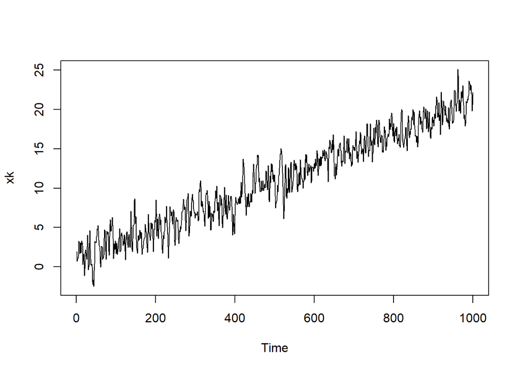

```r
load("a3_q3.Rdata")
plot(xk)
```

```r
lin = 1:1000
ap <- lm(xk~lin)
print(ap)
```

```
##
## Call:
## lm(formula = xk ~ lin)
##
## Coefficients:
## (Intercept)          lin
##     0.87462      0.02012
```

Therefore checking the residuals after eliminating the linear trend we get

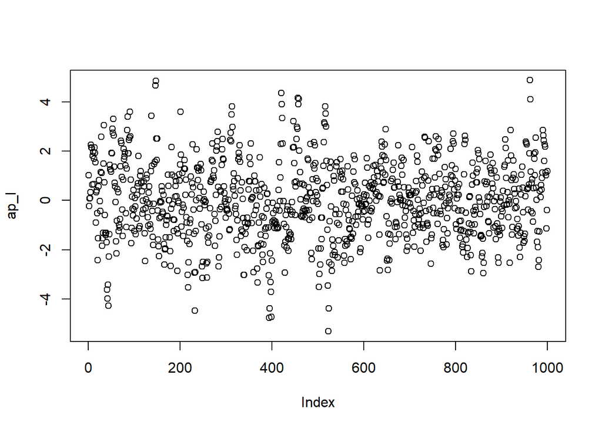

```r
ap_l = ap$residuals
plot(ap_l)
```

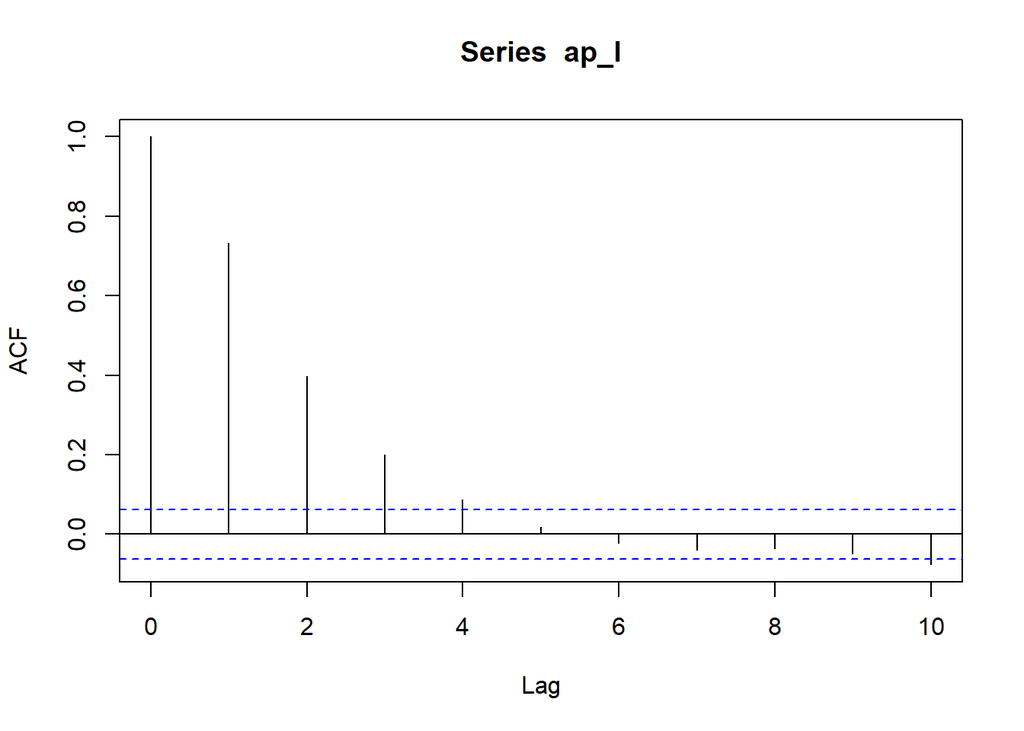

```r
acf(ap_l, lag.max = 10)
```

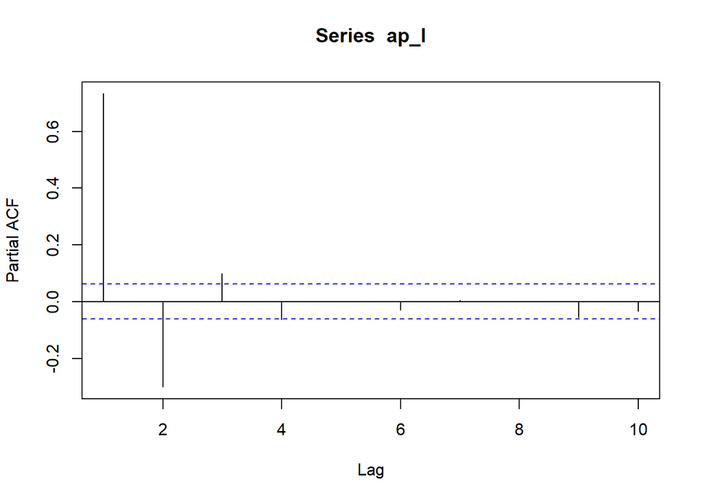

```r
pacf(ap_l, lag.max = 10)
```

Observing the ACF and PACF of the linearly fitted (for trend) series we can either assume MA(4) or AR(3) process.

Starting with MA(4) process

```r
ma4mod <- arima(ap_l,c(0,0,4))
print(ma4mod)
```

```
##
## Call:
## arima(x = ap_l, order = c(0, 0, 4))
##
## Coefficients:
##          ma1     ma2     ma3     ma4  intercept
##       0.9898  0.5448  0.2648  0.0925     0.0043
## s.e.  0.0315  0.0423  0.0407  0.0319     0.0904
##
## sigma^2 estimated as 0.9788:  log likelihood = -1408.72,  aic = 2829.44
```

Observing the coefficients and their standard deviations we can say that the above model fails test for overfitting.

Now checking the fit of AR(3) model,

```r
ar3mod = arima(ap_l, c(3,0,0))
print(ar3mod)
```

```
##
## Call:
## arima(x = ap_l, order = c(3, 0, 0))
##
## Coefficients:
##          ar1      ar2     ar3  intercept
##       0.9858  -0.3988  0.1001     0.0051
## s.e.  0.0315   0.0425  0.0315     0.0999
##
## sigma^2 estimated as 0.9799:  log likelihood = -1409.27,  aic = 2828.53
```

Model passes the test for overfitting

Now checking the underfitting

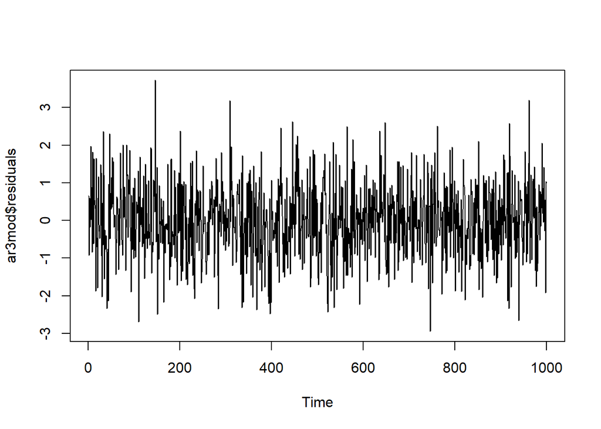

```r
plot(ar3mod$residuals)
```

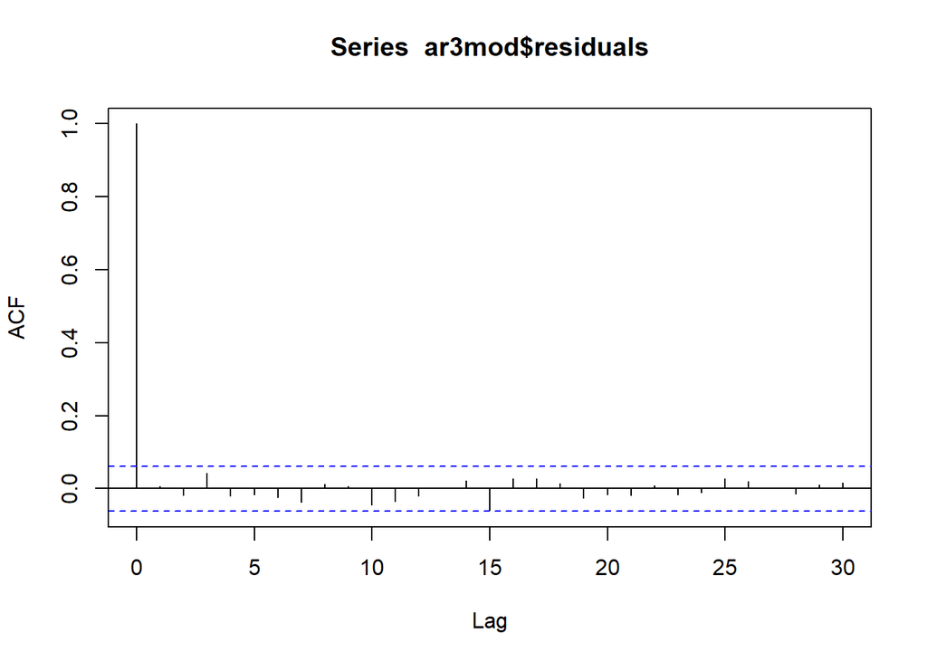

```r
acf(ar3mod$residuals)
```

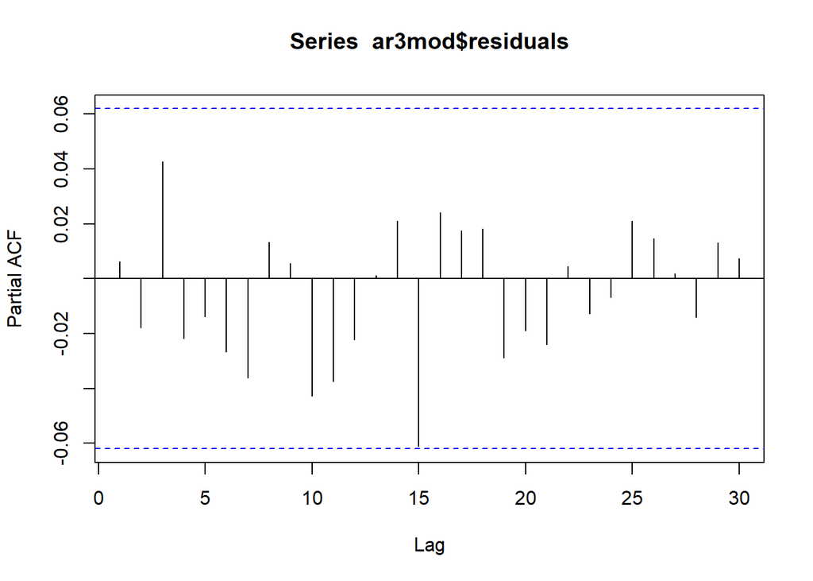

```r
pacf(ar3mod$residuals)
```

Since the residuals show the WN characteristics we can say that the series passes the underfitting test

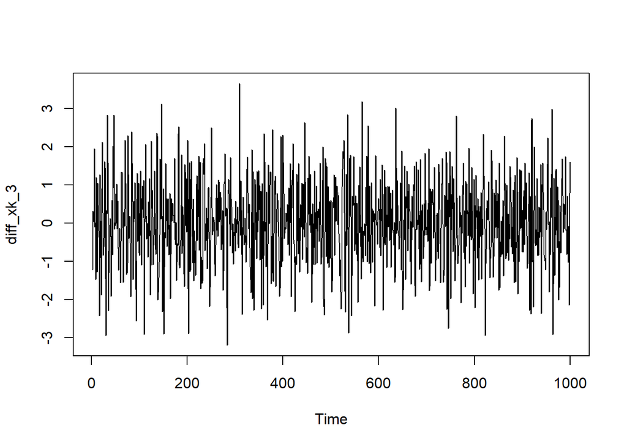

```r
#Differencing the given series in order to remove the linear polynomial trend
diff_xk_3 = diff(xk)
plot(diff_xk_3)
```

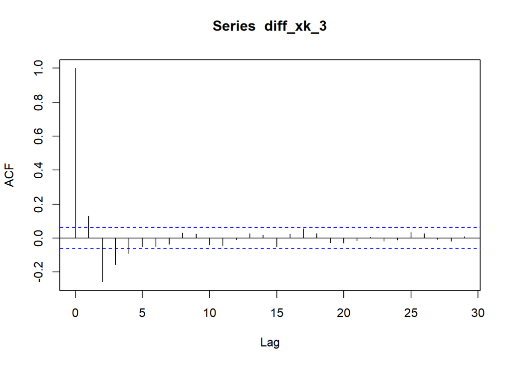

```r
acf(diff_xk_3)
```

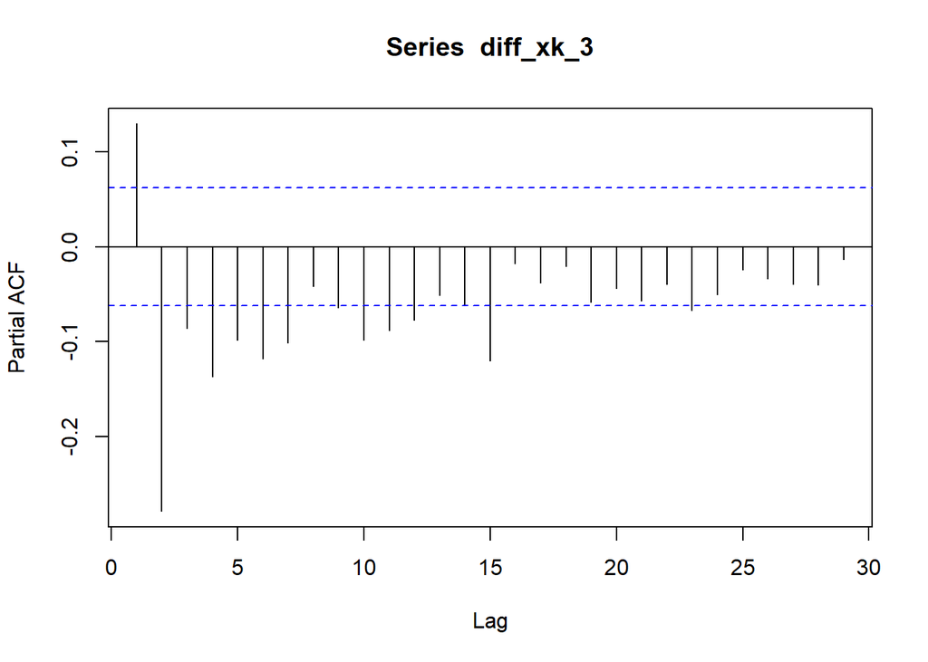

```r
pacf(diff_xk_3)
```

By observing the ACF and PACF of the differenced series, we can say that the series cannot model by purely AR or MA process

Therefore by trial and error ARMA(1,2) model is chosen

```r
arma = arima(diff_xk_3, order = c(1,0,2))
print(arma)
```

```
##
## Call:
## arima(x = diff_xk_3, order = c(1, 0, 2))
##
## Coefficients:
##          ar1      ma1      ma2  intercept
##       0.5575  -0.5685  -0.4315     0.0201
## s.e.  0.0327   0.0352   0.0350     0.0004
##
## sigma^2 estimated as 0.9781:  log likelihood = -1409.24,  aic = 2828.48
```

Coefficients and respective standard deviations checked Test for overfitting passed

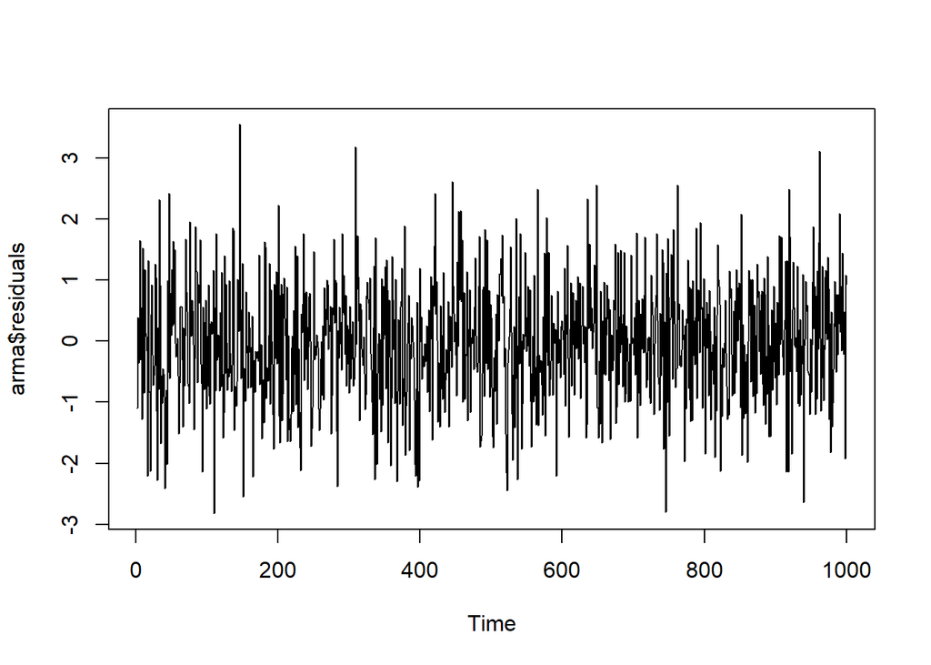

```r
plot(arma$residuals)
```

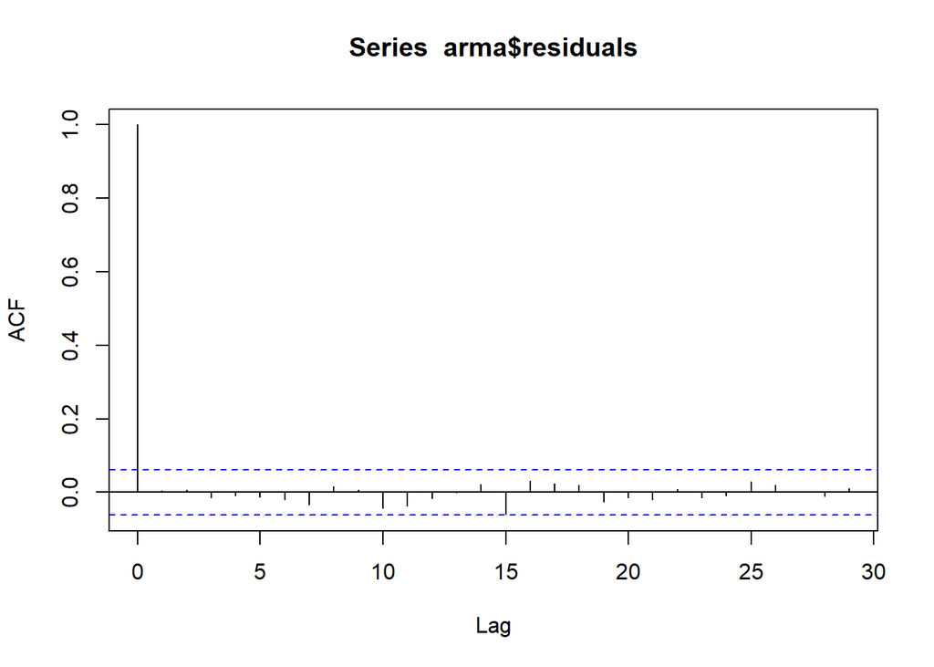

```r
acf(arma$residuals)
```

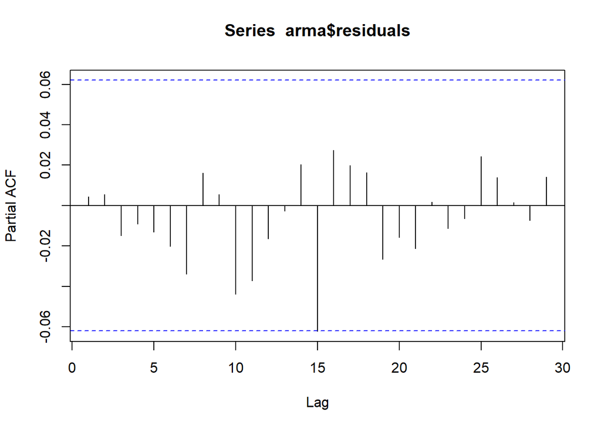

```r
pacf(arma$residuals)
```

Residuals showing the WN characteristics Test for underfitting passed

### Q.4 Variance Non - Stationarity

```r
library(MLmetrics)
```

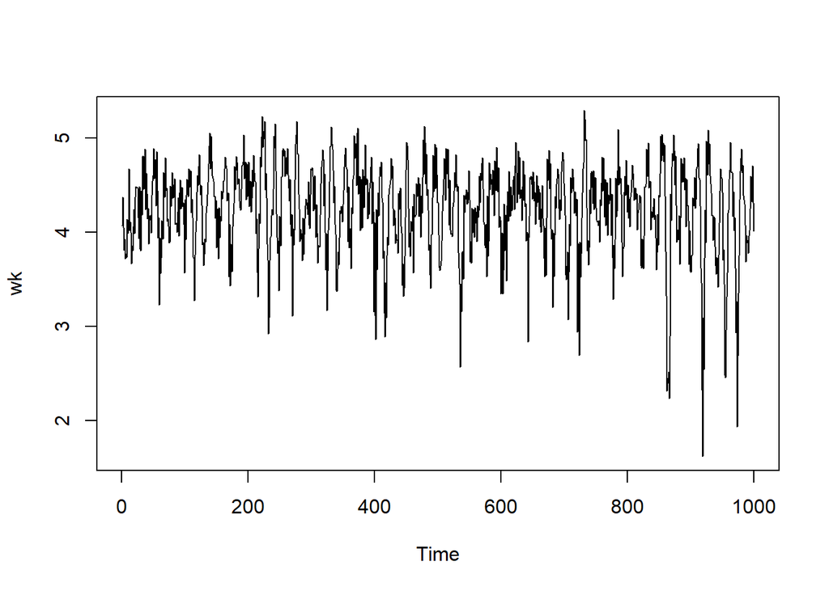

```r
# Loading and Plotting the given data

load("a3_q4.Rdata")

plot(wk)
```

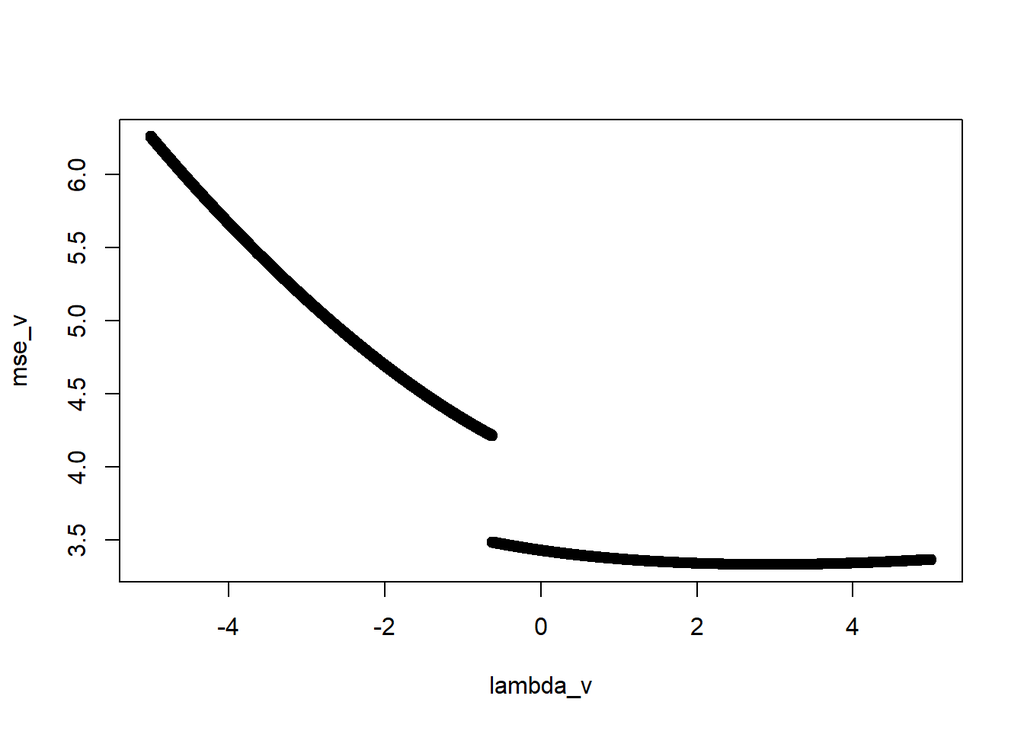

```r
train = wk[1:800] # Training purpose

test = wk[801:1000] #Test data

#List of the Box - Cox transformation parameters
lambda_v = seq(-5,5,0.001)

#Empty matrix for list mse values
mse_v = {}

index = 0


for (lambda in lambda_v) {

  index = index + 1

  if (lambda == 0){

    bxcx = log(wk)
  }

  else{

    bxcx = ((wk)^lambda -1)/lambda

    #Fitting an AR model on the first 800 observations
    armod = ar(bxcx[1:800], aic = TRUE, order.max = 7)

    #One step ahead prediction using filter routine
    test_filter = filter(test, armod$ar, method = "convolution", sides =1 )

    #Trimming the first 'NA' values appearing due to filtering
    mse_v[index] =  MSE(test_filter[(1+armod$order):200],          test[(1+armod$order):200])

  }
}

#Plotting Mean Squared error on each lambda wrt lambda
plot( lambda_v, mse_v)
```

```r
#Finding the optimal lambda

opt_lambda = lambda_v[which.min(mse_v)]
print(opt_lambda)
```

```
## [1] 2.928
```

The above value is the value of the optimal $\lambda$ corresponding to the case where MSE is minimum.

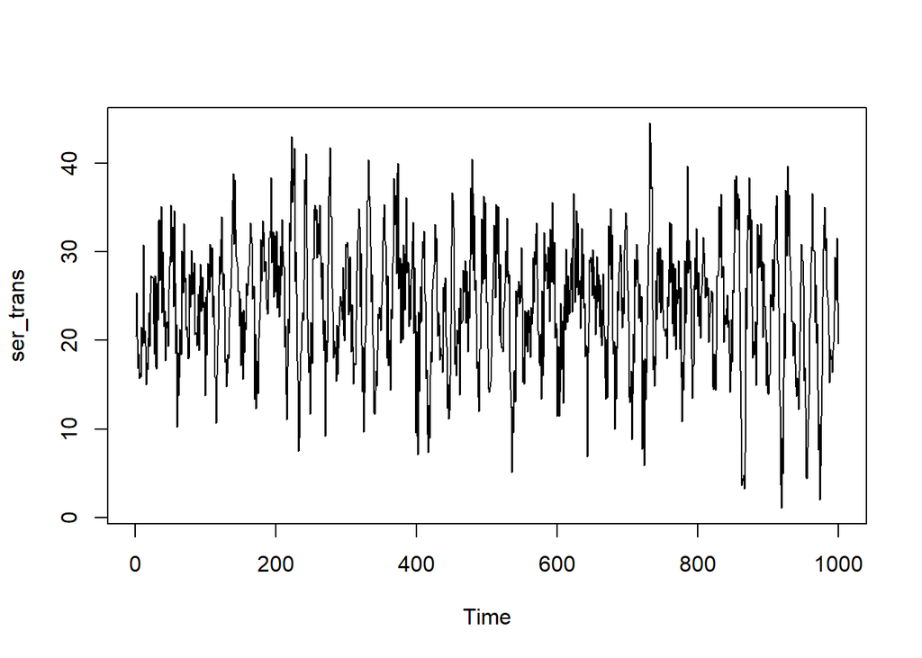

```r
library(forecast)

lambda_bxcx = BoxCox.lambda(wk, method = 'guerrero', lower=-5,upper=5)

#Transformed Series with lambda from the BoxCox routine
ser_bxcx  = BoxCox(wk,lambda_bxcx)

#Series with lambda obtained from the robust code
ser_trans = ((wk)^opt_lambda - 1)/opt_lambda

plot(ser_trans)
```

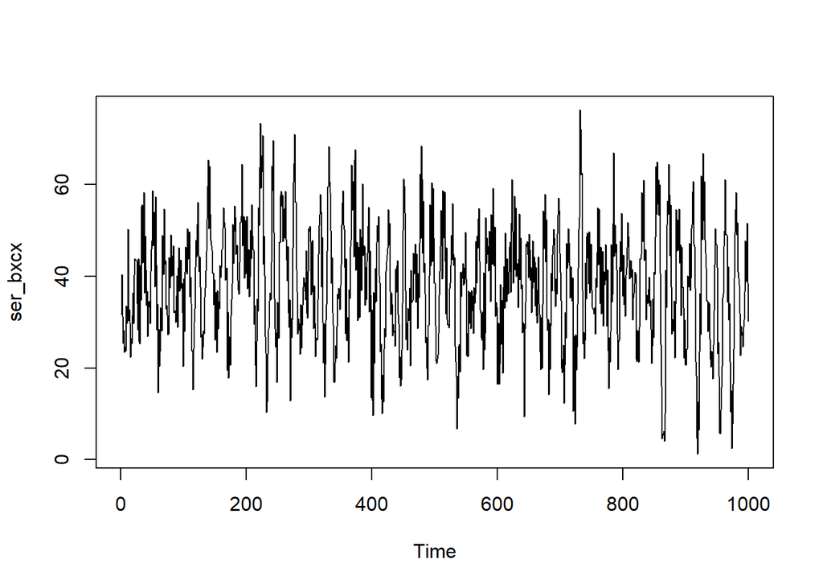

```r
plot(ser_bxcx)
```

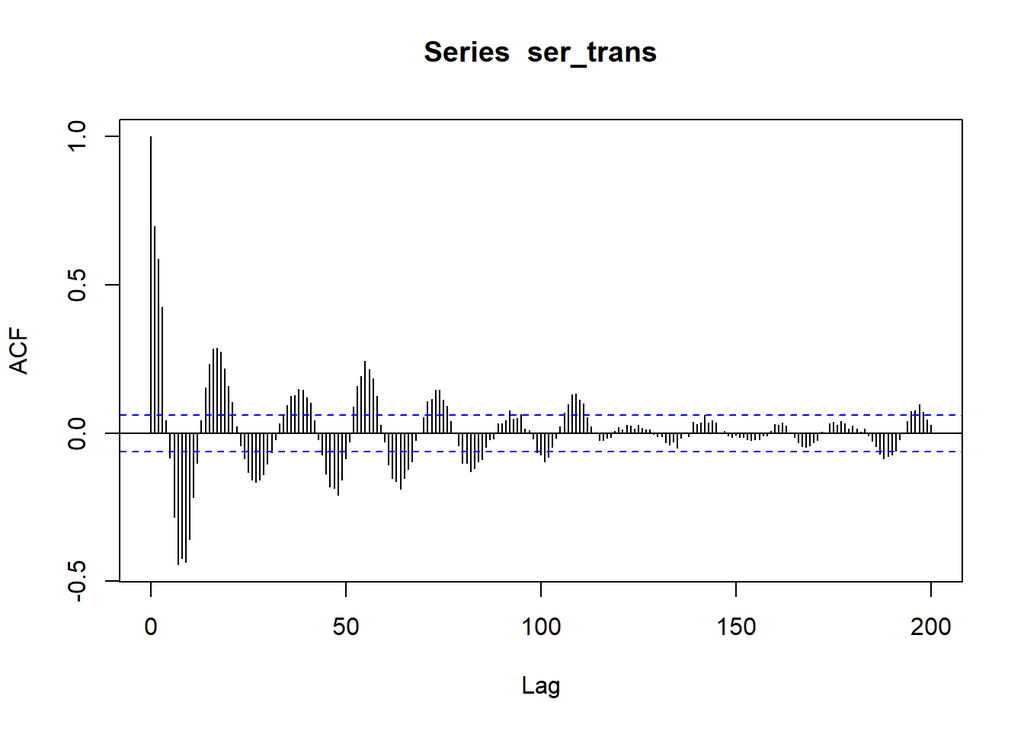

```r
acf(ser_trans, lag.max = 200)
```

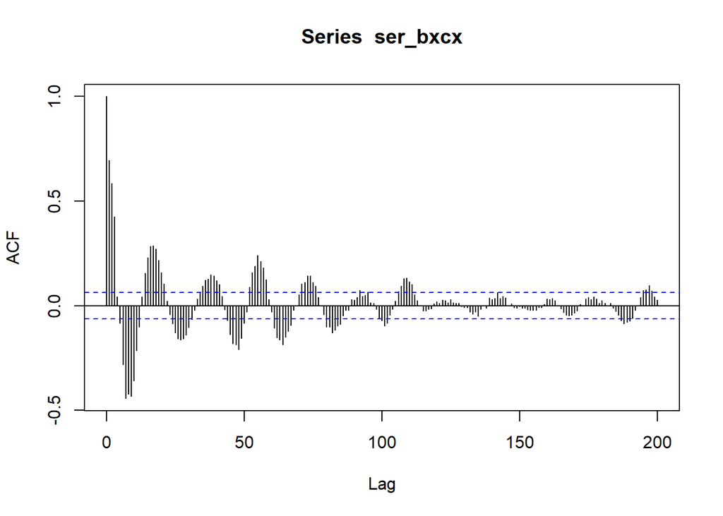

```r
acf(ser_bxcx, lag.max = 200)
```

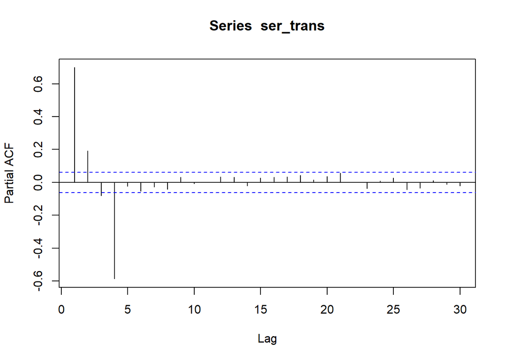

```r
pacf(ser_trans)
```

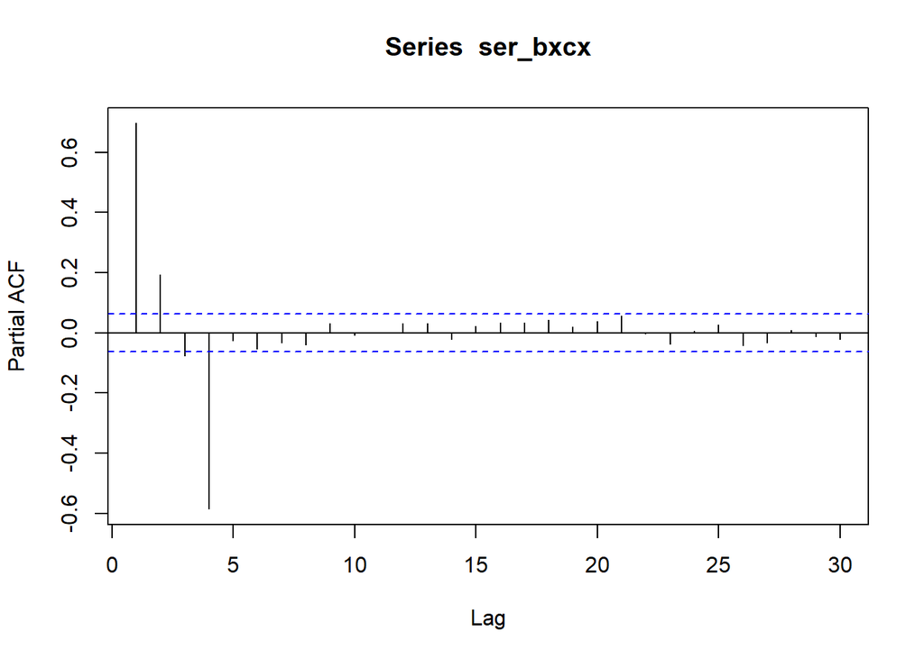

```r
pacf(ser_bxcx)
```

From PACF of the both transformed series we can try building an AR(4) model for both and check whether it’s an optimal fit

```r
armod_tr = arima(ser_trans, c(4,0,0))
armod_bx = arima(ser_bxcx, c(4,0,0))
print(armod_tr)
```

```
##
## Call:
## arima(x = ser_trans, order = c(4, 0, 0))
##
## Coefficients:
##          ar1     ar2     ar3      ar4  intercept
##       0.5321  0.3768  0.2616  -0.5882    23.9859
## s.e.  0.0255  0.0295  0.0295   0.0256     0.3037
##
## sigma^2 estimated as 16.06:  log likelihood = -2808.43,  aic = 5628.86
```